# analysis

```python
import pandas as pd
import numpy as np
import json
```

```python
df = pd.read_excel('../data/raw/tweet_with_predicted_aspect_test.xlsx', sheet_name='Sheet1')
df
```

|  | Date | Text | Brand | Sentimen | Predicted_Aspects | Predicted_Keywords |
| --- | --- | --- | --- | --- | --- | --- |
| 0 | 01/2024 | sumpah iya fore beli kopi toast kerja pulang t... | fore | neutral | Suasana/Tempat; Menu Lain | ke fore, kerja; toast |
| 1 | 01/2024 | fore dark chocom | fore | neutral | Menu Lain | dark choco |
| 2 | 01/2024 | tim matcha green tea classic milo beli fore se... | fore | positive | Kualitas Kopi; Menu Lain | caramel macchiato, enak sih; matcha green tea,... |
| 3 | 01/2024 | fore bisaa turun harga promo goceng dehh | fore | neutral | Harga/Nilai; Promo | turun harga; promo goceng |
| 4 | 01/2024 | fore enak dikantor deket mall hampir beli fore... | fore | positive | Kualitas Kopi; Suasana/Tempat | enaaa; deket mall, dikantor lama |
| ... | ... | ... | ... | ... | ... | ... |
| 2272 | 12/2024 | ih beli fore junior stiker | fore | neutral | Menu Lain | junior, stiker |
| 2273 | 12/2024 | fore junior mantap stiker | fore | positive | Kualitas Kopi; Promo | fore, junior, mantap; stiker |
| 2274 | 12/2024 | ngomong-ngomong menu juniornya fore enak | fore | positive | Menu Lain | menu juniornya, enak |
| 2275 | 12/2024 | fore belinya junior wkwkwk | fore | negative | Menu Lain | fore, junior |
| 2276 | 12/2024 | beli fore junior dikasi stiker | fore | neutral | Layanan Pelanggan; Promo | dikasi stiker; stiker |

2277 rows × 6 columns

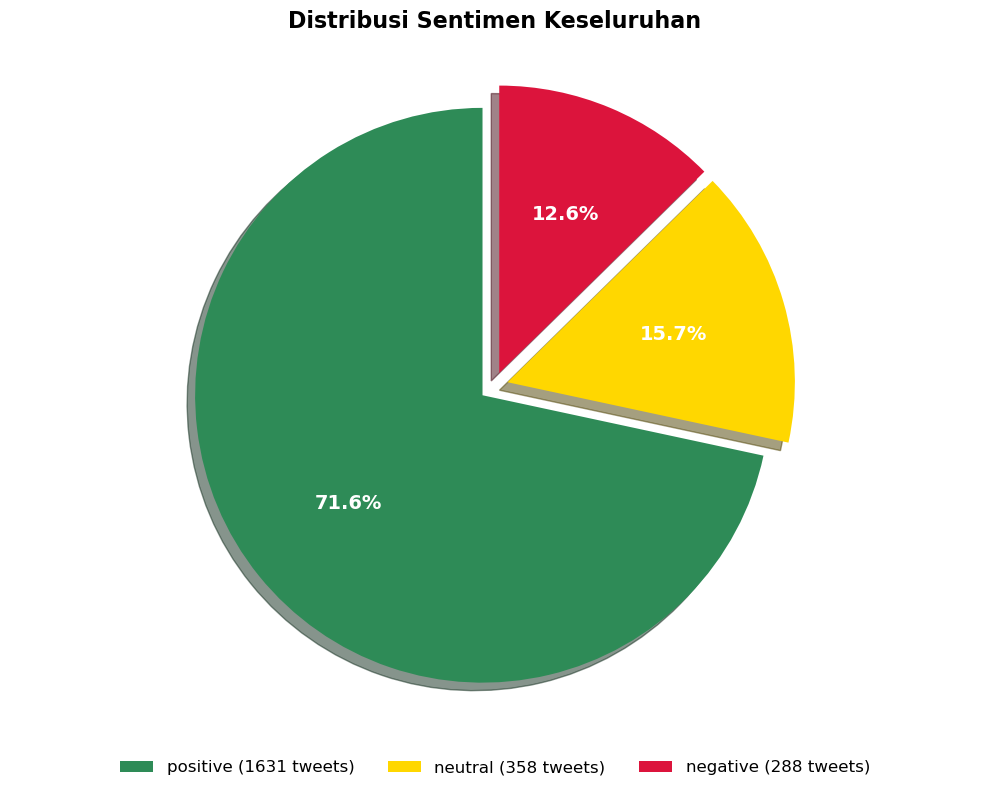

```python
import matplotlib.pyplot as plt
import seaborn as sns

sentiment_counts = df['Sentimen'].value_counts()

plt.figure(figsize=(10, 8))
colors = ['#2E8B57', '#FFD700', '#DC143C']  # Green, Gold, Red
wedges, texts, autotexts = plt.pie(sentiment_counts,
                                  autopct='%1.1f%%',
                                  startangle=90,
                                  colors=colors,
                                  explode=(0.05, 0.05, 0.05),
                                  shadow=True,
                                  textprops={'fontsize': 12, 'fontweight': 'bold'})

# Enhance the percentage labels
for autotext in autotexts:
    autotext.set_color('white')
    autotext.set_fontsize(14)
    autotext.set_fontweight('bold')



plt.title('Distribusi Sentimen Keseluruhan', fontsize=16, fontweight='bold', pad=20)

# Create horizontal legend below the chart
legend_labels = [f'{label} ({count} tweets)' for label, count in zip(sentiment_counts.index, sentiment_counts.values)]
plt.legend(wedges, legend_labels, loc='upper center', bbox_to_anchor=(0.5, -0.05), ncol=3,
           fontsize=12, frameon=False)

plt.axis('equal')
plt.tight_layout()
plt.show()
```

*Summary*

1. Proporsi klasifikasi sentimen didominasi oleh sentimen positif dengan 1631 tweet dari total 2277 tweet (71.6%)
2. Dominasi sentimen positif bisa menjadi dasar untuk penelitian lebih lanjut untuk mendapatkan wawasan keterlibatan pelanggan, preferensi, dan dampaknya kepada brand target

**ASPECT-BASED SENTIMENT ANLYSIS**

```python
# Split rows where Predicted_Aspects has multiple values
df_expanded = df.copy()
df_expanded['Predicted_Aspects'] = df_expanded['Predicted_Aspects'].str.split('; ')
df_expanded = df_expanded.explode('Predicted_Aspects').reset_index(drop=True)
df_expanded
```

|  | Date | Text | Brand | Sentimen | Predicted_Aspects | Predicted_Keywords |
| --- | --- | --- | --- | --- | --- | --- |
| 0 | 01/2024 | sumpah iya fore beli kopi toast kerja pulang t... | fore | neutral | Suasana/Tempat | ke fore, kerja; toast |
| 1 | 01/2024 | sumpah iya fore beli kopi toast kerja pulang t... | fore | neutral | Menu Lain | ke fore, kerja; toast |
| 2 | 01/2024 | fore dark chocom | fore | neutral | Menu Lain | dark choco |
| 3 | 01/2024 | tim matcha green tea classic milo beli fore se... | fore | positive | Kualitas Kopi | caramel macchiato, enak sih; matcha green tea,... |
| 4 | 01/2024 | tim matcha green tea classic milo beli fore se... | fore | positive | Menu Lain | caramel macchiato, enak sih; matcha green tea,... |
| ... | ... | ... | ... | ... | ... | ... |
| 2949 | 12/2024 | fore junior mantap stiker | fore | positive | Promo | fore, junior, mantap; stiker |
| 2950 | 12/2024 | ngomong-ngomong menu juniornya fore enak | fore | positive | Menu Lain | menu juniornya, enak |
| 2951 | 12/2024 | fore belinya junior wkwkwk | fore | negative | Menu Lain | fore, junior |
| 2952 | 12/2024 | beli fore junior dikasi stiker | fore | neutral | Layanan Pelanggan | dikasi stiker; stiker |
| 2953 | 12/2024 | beli fore junior dikasi stiker | fore | neutral | Promo | dikasi stiker; stiker |

2954 rows × 6 columns

```python
# Remove rows where Predicted_Aspects is 'nan'
df_expanded = df_expanded[df_expanded['Predicted_Aspects'] != 'nan']
df_expanded = df_expanded[df_expanded['Predicted_Aspects'] != 'ERROR']
print(df_expanded['Predicted_Aspects'].value_counts())
```

```
Predicted_Aspects
Kualitas Kopi        1181
Menu Lain             496
Harga/Nilai           301
Suasana/Tempat        273
Promo                 171
Layanan Pelanggan      62
Name: count, dtype: int64
```

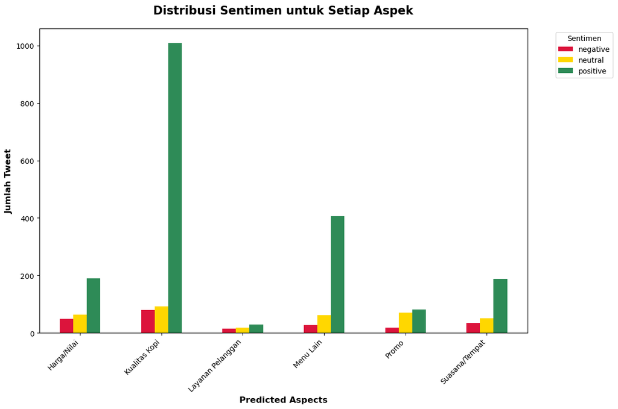

```
Distribusi Sentimen per Aspek:
Sentimen           negative  neutral  positive
Predicted_Aspects
Harga/Nilai              49       63       189
Kualitas Kopi            80       92      1009
Layanan Pelanggan        15       18        29
Menu Lain                27       62       407
Promo                    18       71        82
Suasana/Tempat           34       51       188

Persentase Sentimen per Aspek:
Sentimen           negative  neutral  positive
Predicted_Aspects
Harga/Nilai            16.3     20.9      62.8
Kualitas Kopi           6.8      7.8      85.4
Layanan Pelanggan      24.2     29.0      46.8
Menu Lain               5.4     12.5      82.1
Promo                  10.5     41.5      48.0
Suasana/Tempat         12.5     18.7      68.9
```

```python
# Create a crosstab to see sentiment distribution for each aspect
aspect_sentiment = pd.crosstab(df_expanded['Predicted_Aspects'], df_expanded['Sentimen'])

# Create a stacked bar chart
plt.figure(figsize=(12, 8))
aspect_sentiment.plot(kind='bar', stacked=False, color=['#DC143C', '#FFD700', '#2E8B57'],
                     figsize=(12, 8))

plt.title('Distribusi Sentimen untuk Setiap Aspek', fontsize=16, fontweight='bold', pad=20)
plt.xlabel('Predicted Aspects', fontsize=12, fontweight='bold')
plt.ylabel('Jumlah Tweet', fontsize=12, fontweight='bold')
plt.legend(title='Sentimen', bbox_to_anchor=(1.05, 1), loc='upper left')
plt.xticks(rotation=45, ha='right')
plt.tight_layout()
plt.show()

# Display the numerical breakdown
print("Distribusi Sentimen per Aspek:")
print(aspect_sentiment)
print("\nPersentase Sentimen per Aspek:")
aspect_sentiment_pct = pd.crosstab(df_expanded['Predicted_Aspects'], df_expanded['Sentimen'], normalize='index') * 100
print(aspect_sentiment_pct.round(1))
```

*Summary*

1. Seluruh aspek didominasi oleh sentimen positif.
2. Aspek Kualitas Kopi sering dibahas oleh pelanggan, serta pelanggan sering beropini positif terhadap brand ini. Rincian Aspek Kualitas Kopi terdiri dari 1,009 tweet positif (44.31%) dari total 2,277 tweet

**TOP 10 WORD**

```python
from collections import Counter
import re

# Create top 10 words by aspects and sentiment


# 0. Definisikan semua stopwords sekaligus (brand + umum)
brand_stopwords = {
    'fore', 'tomoro', 'kopi', 'kenangan', 'kopi kenangan',
    'point', 'coffee', 'point coffee',
    'kopikenangan', 'pointcoffee', 'kenangancoffee',
    'tuku', 'kopken', 'janjiw', 'famima', 'calf'
}

common_stopwords = {
    'dan', 'yang', 'ini', 'itu', 'dari', 'untuk', 'dengan',
    'ke', 'pada', 'atau', 'yg', 'aku', 'kamu', 'kita',
    'lagi', 'lagi', 'boleh', 'mau', 'ga', 'gak', 'aja',
    'sih', 'si', 'nya', 'sama', 'bisa', 'ada', 'juga',
    'buat', 'kayak', 'tuh', 'pake', 'tp', 'nama'
}
stop_words = set(w.lower() for w in brand_stopwords | common_stopwords)

# 1. Fungsi untuk split & filter keywords
def extract_words(keywords_text):
    if pd.isna(keywords_text) or not keywords_text:
        return []
    # Split di koma atau titik-koma
    tokens = re.split(r'[;,]', str(keywords_text))
    cleaned = []
    for tok in tokens:
        w = tok.strip().lower()
        # Hapus stopwords, brand, dan kata terlalu pendek
        if len(w) > 2 and w not in stop_words:
            cleaned.append(w)
    return cleaned

# Create a comprehensive analysis
results = {}

# Get unique aspects and sentiments
aspects = df_expanded['Predicted_Aspects'].dropna().unique()
sentiments = df_expanded['Sentimen'].unique()

print("TOP 10 KATA BERDASARKAN ASPEK DAN SENTIMEN\n" + "="*50)

for aspect in aspects:
    results[aspect] = {}
    print(f"\n📊 ASPEK: {aspect.upper()}")
    print("-" * 40)

    for sentiment in sentiments:
        # Filter data for specific aspect and sentiment
        filtered_data = df_expanded[
            (df_expanded['Predicted_Aspects'] == aspect) &
            (df_expanded['Sentimen'] == sentiment)
        ]

        if len(filtered_data) > 0:
            # Extract all words from keywords for this combination
            all_words = []
            for keywords in filtered_data['Predicted_Keywords']:
                all_words.extend(extract_words(keywords))

            # Count word frequencies
            word_counts = Counter(all_words)
            top_10 = word_counts.most_common(10)

            results[aspect][sentiment] = top_10

            print(f"\n{sentiment.upper()} ({len(filtered_data)} tweets):")
            if top_10:
                for i, (word, count) in enumerate(top_10, 1):
                    print(f"  {i:2d}. {word:<15} ({count:2d}x)")
            else:
                print("     Tidak ada kata kunci yang tersedia")
        else:
            print(f"\n{sentiment.upper()}: Tidak ada data")

print("\n" + "="*50)
print("RINGKASAN ANALISIS SELESAI")
```

```
TOP 10 KATA BERDASARKAN ASPEK DAN SENTIMEN
==================================================

📊 ASPEK: SUASANA/TEMPAT
----------------------------------------

NEUTRAL (51 tweets):
   1. couvee          ( 3x)
   2. outlet          ( 3x)
   3. sby             ( 2x)
   4. sushi tei       ( 2x)
   5. fami fore       ( 2x)
   6. jember          ( 2x)
   7. buka            ( 2x)
   8. disini          ( 2x)
   9. uang            ( 2x)
  10. top 3           ( 2x)

POSITIVE (188 tweets):
   1. enak            (18x)
   2. nongkrong       ( 6x)
   3. enak banget     ( 6x)
   4. suka            ( 5x)
   5. disini          ( 5x)
   6. andalanque      ( 4x)
   7. jatinangor      ( 3x)
   8. coffee shop     ( 3x)
   9. rumah           ( 3x)
  10. enakk           ( 3x)

NEGATIVE (34 tweets):
   1. versi           ( 3x)
   2. disini          ( 3x)
   3. gak hore        ( 3x)
   4. matcha          ( 2x)
   5. penasaran       ( 2x)
   6. tempatku        ( 1x)
   7. gada fore       ( 1x)
   8. ihh sebel banget ( 1x)
   9. deket fore      ( 1x)
```

[output cut: 211 more lines]

```

NEGATIVE (15 tweets):
   1. normal ice gak penuh ( 2x)
   2. team more ice   ( 2x)
   3. sweet           ( 2x)
   4. normal          ( 2x)
   5. pesen           ( 2x)
   6. min             ( 1x)
   7. sertif halal    ( 1x)
   8. anjing males    ( 1x)
   9. gula pas kemanisan ( 1x)
  10. normal sugarnya manis banget ( 1x)

==================================================
RINGKASAN ANALISIS SELESAI
```

```python
# Convert results dictionary to a DataFrame
rows = []
for aspect in results:
    for sentiment in results[aspect]:
        for rank, (word, count) in enumerate(results[aspect][sentiment], 1):
            rows.append({
                'Aspect': aspect,
                'Sentiment': sentiment,
                'Rank': rank,
                'Word': word,
                'Count': count
            })

results_df = pd.DataFrame(rows)
results_df
```

|  | Aspect | Sentiment | Rank | Word | Count |
| --- | --- | --- | --- | --- | --- |
| 0 | Suasana/Tempat | neutral | 1 | couvee | 3 |
| 1 | Suasana/Tempat | neutral | 2 | outlet | 3 |
| 2 | Suasana/Tempat | neutral | 3 | sby | 2 |
| 3 | Suasana/Tempat | neutral | 4 | sushi tei | 2 |
| 4 | Suasana/Tempat | neutral | 5 | fami fore | 2 |
| ... | ... | ... | ... | ... | ... |
| 175 | Layanan Pelanggan | negative | 6 | min | 1 |
| 176 | Layanan Pelanggan | negative | 7 | sertif halal | 1 |
| 177 | Layanan Pelanggan | negative | 8 | anjing males | 1 |
| 178 | Layanan Pelanggan | negative | 9 | gula pas kemanisan | 1 |
| 179 | Layanan Pelanggan | negative | 10 | normal sugarnya manis banget | 1 |

180 rows × 5 columns

*Summary*

1. Aspek Kualitas Kopi dengan sentimen positif sering dibahas, dengan top word: 'enak','matcha','enak banget','arabica','suka','creamy','kopinya'.
2. Aspek Menu Lain menjadi urutan ke-2 dengan sentimen positif, dengan top word: 'enak','matcha','matchanya','butterscotch','matcha frappe'
3. Aspek Harga/Nilai menduduki urutan ke-3 dengan sentimen positif, dengan top word: 'enak','diskon 50','promo','murah','diskon'
4. Aspek Suasana/Tempat dengan sentimen positif, dengan top word: 'enak','nongkrong','enak banget','disini','suka'.
5. Aspek Promo dengan sentimen positif, dengan top word: 'promo','diskon 50','diskon,'enak'
6. Aspek Layanan Pelanggan dengan sentimen positif, dengan top word: 'enak','andalanque','isinya 5','enak banget'

**Top Keywords per Aspect + Sentiment**

```python
df_keywords = df.copy()
# Filter out rows with NaN values first
df_keywords = df_keywords.dropna(subset=['Predicted_Aspects', 'Predicted_Keywords'])

# Split Aspects dan Keywords jadi list
df_keywords['Predicted_Aspects'] = df_keywords['Predicted_Aspects'].str.split('; ')
df_keywords['Predicted_Keywords'] = df_keywords['Predicted_Keywords'].str.split('; ')

# Pastikan jumlah aspek dan keyword per tweet sama
assert df_keywords['Predicted_Aspects'].apply(len).equals(df_keywords['Predicted_Keywords'].apply(len)), "Jumlah aspek dan keyword tidak sama per tweet!"
```

```python
# Explode untuk aspek dan keyword secara paralel
df_keywords = df_keywords.explode(['Predicted_Aspects', 'Predicted_Keywords'])
# Bersihkan spasi
df_keywords['Predicted_Aspects'] = df_keywords['Predicted_Aspects'].str.strip()
df_keywords['Predicted_Keywords'] = df_keywords['Predicted_Keywords'].str.strip()
```

```python
# Hitung frekuensi
keyword_freq = df_keywords.groupby(['Predicted_Aspects', 'Sentimen', 'Predicted_Keywords']).size().reset_index(name='Frequency')

# Urutkan dari frekuensi tertinggi
keyword_freq = keyword_freq.sort_values(by=['Predicted_Aspects', 'Sentimen', 'Frequency'], ascending=[True, True, False])
```

```python
keyword_freq
```

|  | Predicted_Aspects | Sentimen | Predicted_Keywords | Frequency |
| --- | --- | --- | --- | --- |
| 20 | Harga/Nilai | negative | mahal | 5 |
| 0 | Harga/Nilai | negative | 10rb, uk segelas kopi fore reguler | 1 |
| 1 | Harga/Nilai | negative | 12k, pot | 1 |
| 2 | Harga/Nilai | negative | 50, diskon | 1 |
| 3 | Harga/Nilai | negative | beli, mikir2, enakan | 1 |
| ... | ... | ... | ... | ... |
| 2267 | Suasana/Tempat | positive | tomoro, malang, kopi jaya, ponorogo, cobain | 1 |
| 2268 | Suasana/Tempat | positive | tuku, dipekanbaru, fore, kopi kenangan, point ... | 1 |
| 2269 | Suasana/Tempat | positive | tuku, point coffee, tomoro, fore | 1 |
| 2270 | Suasana/Tempat | positive | tutup, ditempatkuuu | 1 |
| 2271 | Suasana/Tempat | positive | ukuran cafe, cabang nya dikit | 1 |

2272 rows × 4 columns

```python
# Ambil top 5 keyword per kombinasi Aspek + Sentimen
top_n = 5

top_keywords = keyword_freq.groupby(['Predicted_Aspects', 'Sentimen']).head(top_n).reset_index(drop=True)
top_keywords
```

|  | Predicted_Aspects | Sentimen | Predicted_Keywords | Frequency |
| --- | --- | --- | --- | --- |
| 0 | Harga/Nilai | negative | mahal | 5 |
| 1 | Harga/Nilai | negative | 10rb, uk segelas kopi fore reguler | 1 |
| 2 | Harga/Nilai | negative | 12k, pot | 1 |
| 3 | Harga/Nilai | negative | 50, diskon | 1 |
| 4 | Harga/Nilai | negative | beli, mikir2, enakan | 1 |
| ... | ... | ... | ... | ... |
| 85 | Suasana/Tempat | positive | famima | 4 |
| 86 | Suasana/Tempat | positive | fore | 4 |
| 87 | Suasana/Tempat | positive | dom surabaya, outlet | 2 |
| 88 | Suasana/Tempat | positive | fore, famima | 2 |
| 89 | Suasana/Tempat | positive | jatinangor | 2 |

90 rows × 4 columns

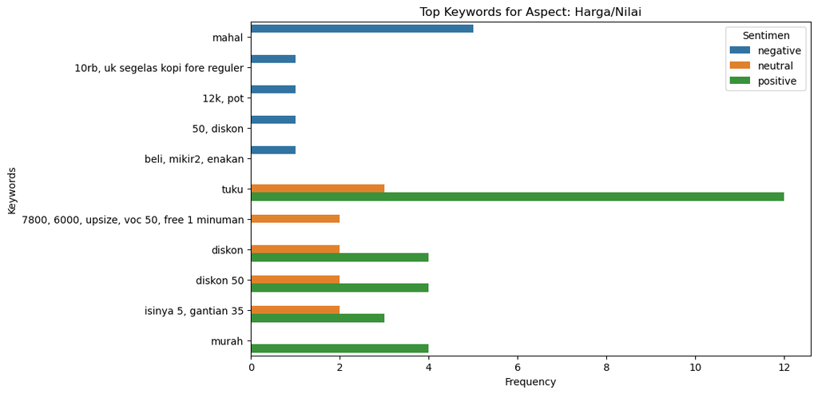

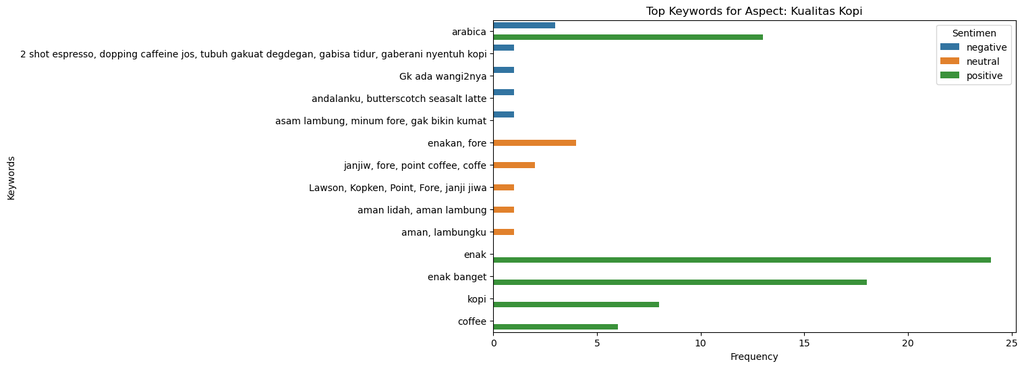

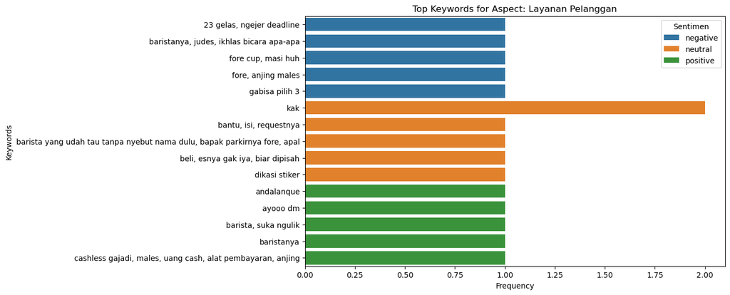

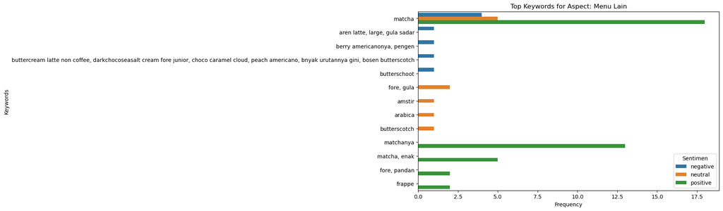

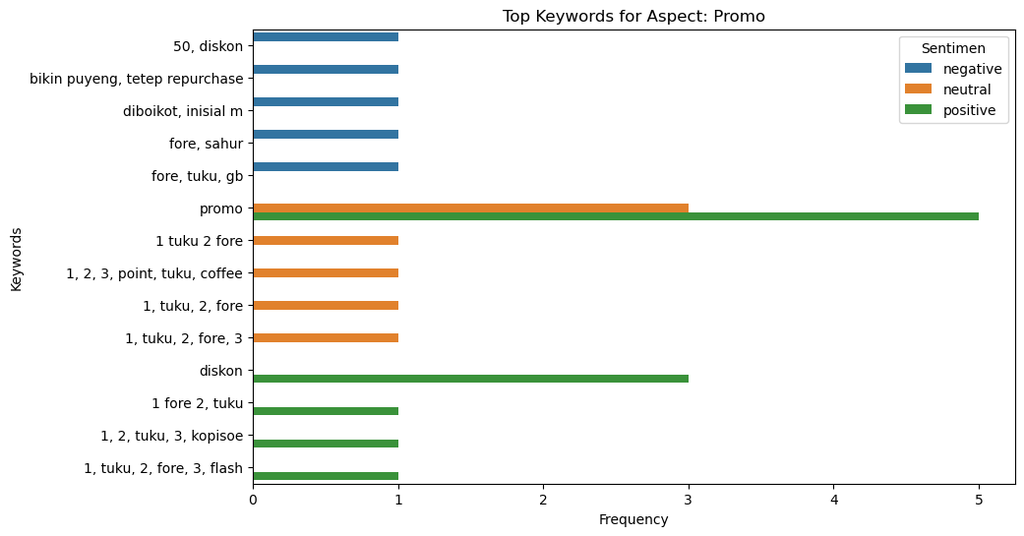

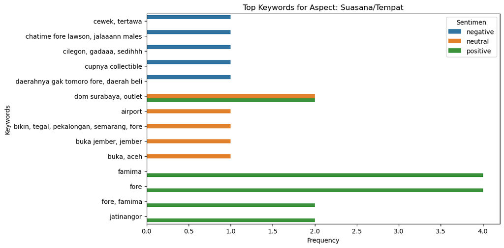

```python
# Visualisasi top keywords per aspek dan sentimen
for aspect in top_keywords['Predicted_Aspects'].unique():
    plt.figure(figsize=(10, 6))
    sns.barplot(
        data=top_keywords[top_keywords['Predicted_Aspects'] == aspect],
        x='Frequency', y='Predicted_Keywords', hue='Sentimen'
    )
    plt.title(f'Top Keywords for Aspect: {aspect}')
    plt.xlabel('Frequency')
    plt.ylabel('Keywords')
    plt.legend(title='Sentimen')
    plt.show()
```

**Time Series Sentiment Analysis**

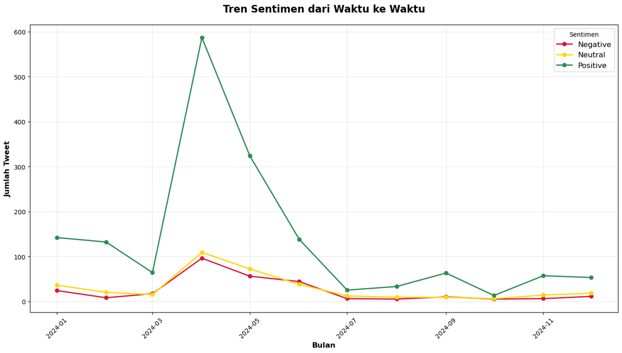

```
Data Time Series Sentimen:
Sentimen    negative  neutral  positive
Date
2024-01-01        24       36       142
2024-02-01         8       20       132
2024-03-01        17       15        64
2024-04-01        96      109       587
2024-05-01        56       72       324
2024-06-01        44       38       138
2024-07-01         6       12        25
2024-08-01         5        9        33
2024-09-01        10        9        63
2024-10-01         5        6        13
2024-11-01         6       14        57
2024-12-01        11       18        53
```

```python
# Convert Date column to datetime and create time series plot
df['Date'] = pd.to_datetime(df['Date'], format='%m/%Y')

# Group by Date and Sentiment to count tweets per month
time_series_data = df.groupby(['Date', 'Sentimen']).size().reset_index(name='Count')

# Pivot the data for easier plotting
time_series_pivot = time_series_data.pivot(index='Date', columns='Sentimen', values='Count').fillna(0)

# Create the time series plot
plt.figure(figsize=(14, 8))
colors = {'positive': '#2E8B57', 'neutral': '#FFD700', 'negative': '#DC143C'}

for sentiment in time_series_pivot.columns:
    plt.plot(time_series_pivot.index, time_series_pivot[sentiment],
             marker='o', linewidth=2, markersize=6,
             color=colors[sentiment], label=sentiment.capitalize())

plt.title('Tren Sentimen dari Waktu ke Waktu', fontsize=16, fontweight='bold', pad=20)
plt.xlabel('Bulan', fontsize=12, fontweight='bold')
plt.ylabel('Jumlah Tweet', fontsize=12, fontweight='bold')
plt.legend(title='Sentimen', fontsize=12)
plt.grid(True, alpha=0.3)
plt.xticks(rotation=45)
plt.tight_layout()
plt.show()

# Display the numerical data
print("Data Time Series Sentimen:")
print(time_series_pivot)
```

```python
# Analyze what happened in April 2024
april_data = df[df['Date'] == '2024-04-01']

print("ANALISIS APRIL 2024")
print("=" * 50)
print(f"Total tweets di April 2024: {len(april_data)}")
print(f"Distribusi sentimen:")
print(april_data['Sentimen'].value_counts())
print(f"Persentase sentimen:")
print((april_data['Sentimen'].value_counts() / len(april_data) * 100).round(1))

# Analyze aspects mentioned in April
april_expanded = april_data.copy()
april_expanded['Predicted_Aspects'] = april_expanded['Predicted_Aspects'].str.split('; ')
april_expanded = april_expanded.explode('Predicted_Aspects').reset_index(drop=True)
april_expanded = april_expanded[april_expanded['Predicted_Aspects'].notna()]
april_expanded = april_expanded[april_expanded['Predicted_Aspects'] != 'nan']

print(f"\nAspek yang paling dibahas di April 2024:")
print(april_expanded['Predicted_Aspects'].value_counts())

# Compare with overall data
print(f"\nPerbandingan dengan data keseluruhan:")
print("April 2024 vs Keseluruhan:")
print(f"April: {len(april_data)} tweets ({len(april_data)/len(df)*100:.1f}% dari total)")
print(f"Sentimen positif April: {len(april_data[april_data['Sentimen']=='positive'])/len(april_data)*100:.1f}%")
print(f"Sentimen positif keseluruhan: {len(df[df['Sentimen']=='positive'])/len(df)*100:.1f}%")
```

```
ANALISIS APRIL 2024
==================================================
Total tweets di April 2024: 792
Distribusi sentimen:
Sentimen
positive    587
neutral     109
negative     96
Name: count, dtype: int64
Persentase sentimen:
Sentimen
positive    74.1
neutral     13.8
negative    12.1
Name: count, dtype: float64

Aspek yang paling dibahas di April 2024:
Predicted_Aspects
Kualitas Kopi        410
Menu Lain            117
Harga/Nilai           97
Suasana/Tempat        80
Promo                 39
Layanan Pelanggan     11
ERROR                  1
Name: count, dtype: int64

Perbandingan dengan data keseluruhan:
April 2024 vs Keseluruhan:
April: 792 tweets (34.8% dari total)
Sentimen positif April: 74.1%
Sentimen positif keseluruhan: 71.6%
```